# Lab 9 - Analysis of Variance

Katherine Filpo

3/4/2020

## Lab 9: Interactions

### Question 1 - effects on shoot length

H<sub>0</sub>: There is no effect of water treatment or soil on shoot length.

H<sub>A</sub>: There is an effect of water treament or soil on shoot length.

**was supposed to have 6 total hypothesis here and for question 2 green~soil+water+soil:water

```r
model_1 <-aov(RADISH$GREEN ~ factor(RADISH$WATER)+factor(RADISH$SOIL) +factor(RADISH$SOIL:RADISH$WATER))
summary(model_1)
```

```
##                                  Df Sum Sq Mean Sq F value   Pr(>F)
## factor(RADISH$WATER)              1 1132.3  1132.3 109.482 3.74e-15 ***
## factor(RADISH$SOIL)               1    4.2     4.2   0.406    0.526
## factor(RADISH$SOIL:RADISH$WATER)  1  200.2   200.2  19.359 4.51e-05 ***
## Residuals                        60  620.5    10.3
## ---
## Signif. codes:  0 '***' 0.001 '**' 0.01 '*' 0.05 '.' 0.1 ' ' 1
```

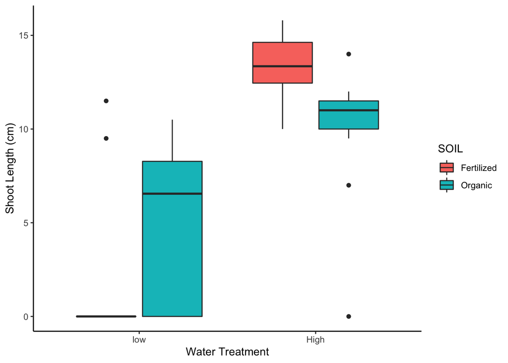

**Figure 1**.Water treatment and soil type has an effect on shoot length (F(1,60)=19.359; P < 0.0001), when taking into account the soil. (the interaction is most important first, and since it is sigficicant, the other hypothesis are discarded)

**Conclusion** After accounting for the soil, there is an effect of water treament on shoot length, so we reject the H<sub>0</sub> and say that the H<sub>A</sub> is supported (*F*<sub>(1,60)</sub>=19.359; *P* < 0.0001).

### Question 2 - effects on root

H<sub>0</sub>: There is no effect of water treatment on root length.

H<sub>A</sub>: There is an effect of water treatment on root length.

roots~soil+water+soil:water

```r
model_2 <-aov(RADISH$ROOTS ~ factor(RADISH$WATER)+factor(RADISH$SOIL) +factor(RADISH$SOIL:RADISH$WATER))
summary(model_2)
```

```
##                                  Df Sum Sq Mean Sq F value   Pr(>F)
## factor(RADISH$WATER)              1  219.8  219.78  31.823 4.84e-07 ***
## factor(RADISH$SOIL)               1   81.9   81.90  11.859  0.00105 **
## factor(RADISH$SOIL:RADISH$WATER)  1   13.3   13.32   1.929  0.17000
## Residuals                        60  414.4    6.91
## ---
## Signif. codes:  0 '***' 0.001 '**' 0.01 '*' 0.05 '.' 0.1 ' ' 1
```

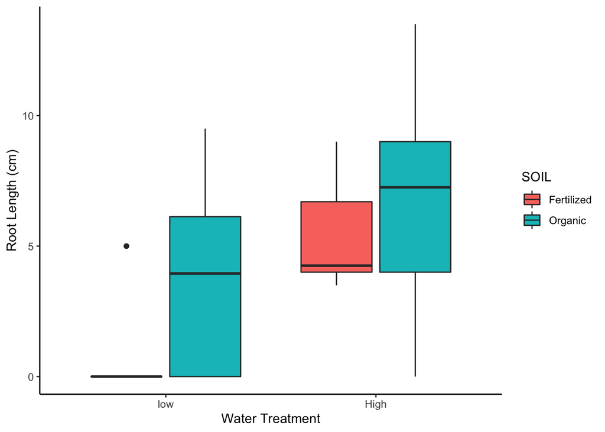

### Question 3

Taking into account all the statistical analysis performed, I would say that the best treatment for the maximum legnt of shoots and roots of the plant is the higher water treatment. Soil does play a slight role in this but can overall be considered to be a lesser effect than the water treatment.